# Project Final Submission Template

### Step 1a: Planning

#### Identify the information in the file your program will read

Describe (all) the information that is available. Be sure to note any surprising or unusual features. (For example, some information sources have missing data, which may be blank or flagged using values like -99, NaN, or something else.)

[output not shown]

**Here are the insignificant columns listed below with a brife summary.**

- Number of updated cases.
- Number of tests
- Rate tests per one million population
- Death rate per one million population
- Number of deaths since last update
- Percentage of death cases per one million population
- Number of tested since last update
- Number of tests taken since last update
- Number of recovered cases since last update
- Percentage of active cases out of total cases
- Number of active cases
- Rate of active cases per one million population
- Number of total cases in the last 14 days
- The total rate of cases per one million population in the last 14 days
- Number of death cases in the last 14 days
- The death rate per one million population in the last 14 days
- Number of total cases in the last 7 days
- The total rate of cases per one million population in the last 7 days
- Number of death cases in the last 7 days
- The death rate in the last 7 days per one million population
- The average total cases in the last 7 days
- The average incidence in the last 7 days
- The average death cases in the last 7 days
- The average death rate in the last 7 days per one million population
- The rate of recovery per one million population

### Step 1b: Planning

#### Brainstorm ideas for what your program will produce

#### Select the idea you will build on for subsequent steps

You must brainstorm at least three ideas for graphs or charts that your program could produce and choose the one that you'd like to work on. You can choose between a line chart, histogram, bar chart, scatterplot, or pie chart.

If you would like to change your project idea from what was described in the proposal, you will need to get permission from your project TA. This is intended to help ensure that your new project idea will meet the requirements of the project. Please see the project proposal for things to be aware of when communicating with your project TA.

1. **Given a specific province name, a time frame, we would find which month has the highest percentage of confirmed cases((confirmed cases/ tested cases)*100). Then plot a bar chart showing the percentage of each month.**
1. Calculate the percentage of confirmed cases((confirmed cases/ tested cases)*100) and plot a line chart showing the percentage vs. total tested cases and find the relationship between the two factors.
1. Plot the peak month of the year for confirmed cases over each month of the year.

### Step 2a: Building

#### Document which information you will represent in your data definitions

Before you design data definitions in the code cell below, you must explicitly document here which information in the file you chose to represent and why that information is crucial to the chart or graph that you'll produce when you complete step 2c.

#### Design data definitions

```python
##################
# Data Definitions
from cs103 import *
from typing import NamedTuple, List
from enum import Enum
import csv
import matplotlib.pyplot as plt

CovidPrname = Enum("CovidPrname", ["CANADA", "NEWFOUNDLAND_AND_LABRADOR", "PEI",
                                 "NOVA_SCOTIA", "NEW_BRUNSWICK", "QUEBEC", "ONTARIO",
                                 "MANITOBA", "SASKATCHEWAN", "ALBERTA", "BRITISH_COLUMBIA",
                                 "YUKON", "NORTHWEST_TERRITORIES", "NUNAVUT", "REPATRIATED_TRAVELLERS"])

# interp. This is the reported names of the provinces/territories; one of Canada(CANADA),
# Newfoundland and Labrador(NEWFOUNDLAND_AND_LABRADOR),
# Prince Edward Island(PEI)
# Nova Scotia (NOVA_SCOTIA)
# New Brunswick (NEW_BRUNSWICK)
# Quebec (QUEBEC)
# Ontario (ONTARIO)
# Manitoba (MANITOBA)
# Saskatchewan (SASKATCHEWAN)
# Alberta (ALBERTA)
# British Columbia (BRITISH_COLUMBIA)
# Yukon (YUKON)
# Northwest Territories (NORTHWEST_TERRITORIES)
# Nunavut (NUNAVUT)
# Repatriated Travellers (REPATRIATED_TRAVELLERS)

# examples are redundant for enumerations

@typecheck
def fn_for_covid_prname(cp: CovidPrname) -> ...:
    # template from enumeration (15 fields)
    if cp == CovidPrname.CANADA:
        return ...
    elif cp == CovidPrname.NEWFOUNDLAND_AND_LABRADOR:
        return ...
    elif cp == CovidPrname.PEI:
        return ...
    elif cp == CovidPrname.NOVA_SCOTIA:
        return ...
    elif cp == CovidPrname.NEW_BRUNSWICK:
        return ...
    elif cp == CovidPrname.QUEBEC:
        return ...
    elif cp == CovidPrname.ONTARIO:
        return ...
    elif cp == CovidPrname.MANITOBA:
        return ...
    elif cp == CovidPrname.SASKATCHEWAN:
        return ...
    elif cp == CovidPrname.ALBERTA:
        return ...
    elif cp == CovidPrname.BRITISH_COLUMBIA:
        return ...
    elif cp == CovidPrname.YUKON:
        return ...
    elif cp == CovidPrname.NORTHWEST_TERRITORIES:
        return ...
    elif cp == CovidPrname.NUNAVUT:
        return ...
    elif cp == CovidPrname.REPATRIATED_TRAVELLERS:
        return ...


CovidData = NamedTuple("CovidData", [("province", CovidPrname),
                                     ("date", str),
                                     ("num_confirmed", int), # in range [0, ...]
                                     ("num_tested", int) # in range [0, ...]
                                     ])
# interp. the data about confirmed and tested covid cases in a province,
# including the reported date (e.g: 2021-06-12).
# num_tested can sometimes be empty(not recorded)


CD1 = CovidData(CovidPrname.BRITISH_COLUMBIA, "2020-09-03", 6041, 317312)
CD2 = CovidData(CovidPrname.ALBERTA, "2021-01-12", 112743, 2860299)


@typecheck
def fn_for_covid_data(cd: CovidData) -> ...:
    # template based on compound (4 fields) and reference rule
    return ...(fn_for_covid_prname(cd.province),
               cd.date,
               cd.num_confirmed,
               cd.num_tested)



# List[Consumed]
# interp. a list of covid data

LOCD0 = []
LOCD1 = [CD1, CD2]
LOCD2 = [CD1, CD2, CovidData(CovidPrname.YUKON, "2020-03-13", 0, 0),
        CovidData(CovidPrname.REPATRIATED_TRAVELLERS, "2020-05-16", 13, 76),
        CovidData(CovidPrname.BRITISH_COLUMBIA, "2021-01-13", 59072, 1008591),
        CovidData(CovidPrname.BRITISH_COLUMBIA, "2020-12-23", 48027, 929744)]

@typecheck
def fn_for_locd(loc: List[CovidData]) -> ...:
    # template based on arbitrary sized data and reference rule
    # description of the accumulator
    acc = ... # type: ...

    for cd in locd:
        acc = ...(fn_for_covid_data(cd), acc)

    return ...(acc)
```

### Step 2b and 2c: Building

#### Design a function to read the information and store it as data in your program

#### Design functions to analyze the data

Complete these steps in the code cell below. You will likely want to rename the analyze function so that the function name describes what your analysis function does.

Unless approved by your project TA, you **cannot** use libraries such as `numpy` or `pandas`. The project is meant as a way for you to demonstrate your knowledge of the learning goals in this course. While it is convinent to use external libraries, it will do all the work and will not help us gauge your mastery of the concepts.

You also cannot use built in list functions (e.g., `sum` or `average`) when writing code to do your substantial computation. Normally we encourage you to make use of what is already available but in this case, the final project involves demonstrating skills from class (e.g., how to work with a list). Using pre-built functions for this does not enable you to demonstrate what you know.

If you wish to change your project idea, you must **first** obtain permission from your TA. When contacting your TA, please provide a valid reason for why you want to change your project. Each time you change your topic idea, your TA will have to evaluate it to see if it will meet all of the project requirements. This is non-trivial task during one of the busiest times of the semester. As such, the deadline for project idea changes will be 3 business days before the deadline. Note that the deliverable deadline will not be extended and there is no compensation for the time you spent on the previous idea.

```python
###########
# Functions

@typecheck
def read(filename: str) -> List[CovidData]:
    """
    reads information from the specified file and returns a list of covid data
    """
    #return []  #stub
    # Template from HtDAP
    # locd contains the result so far
    locd = [] # type: List[CovidData]

    with open(filename) as csvfile:

        reader = csv.reader(csvfile)
        next(reader) # skip header line

        for row in reader:
            # you may not need to store all the rows, and you may need
            # to convert some of the strings to other types
            if is_reliable(row):
                cd = CovidData(parse_covid_prname(row[1]), (row[3]), parse_int(row[5]),
                              parse_int(row[9]))
                locd.append(cd)

    return locd





@typecheck
def parse_covid_prname(covid: str) -> CovidPrname:
    """
    Given a string which must be one of "CANADA",
    "Newfoundland and Labrador", "Prince Edward Island",
    "Nova Scotia", "New Brunswick","Quebec", "Ontario",
    "Manitoba", "Saskatchewan", "Alberta",
    "British Columbia", "Yukon",
    "Northwest Territories", "Nunavut", or
    "Repatriated Travellers", returns the corresponding CovidPrname.
    """
    # return CovidPrname.BRITISH_COLUMBIA
    # template from simple atomic non-distinct
    # return ...(covid) # template

    if covid == "Canada":
        return CovidPrname.CANADA
    elif covid == "Newfoundland and Labrador":
        return CovidPrname.NEWFOUNDLAND_AND_LABRADOR
    elif covid == "Prince Edward Island":
        return CovidPrname.PEI
    elif covid == "Nova Scotia":
        return CovidPrname.NOVA_SCOTIA
    elif covid == "New Brunswick":
        return CovidPrname.NEW_BRUNSWICK
    elif covid == "Quebec":
        return CovidPrname.QUEBEC
    elif covid == "Ontario":
        return CovidPrname.ONTARIO
    elif covid == "Manitoba":
        return CovidPrname.MANITOBA
    elif covid == "Saskatchewan":
        return CovidPrname.SASKATCHEWAN
    elif covid == "Alberta":
        return CovidPrname.ALBERTA
    elif covid == "British Columbia":
        return CovidPrname.BRITISH_COLUMBIA
    elif covid == "Yukon":
        return CovidPrname.YUKON
    elif covid == "Northwest Territories":
        return CovidPrname.NORTHWEST_TERRITORIES
    elif covid == "Nunavut":
        return CovidPrname.NUNAVUT
    elif covid == "Repatriated travellers":
        return CovidPrname.REPATRIATED_TRAVELLERS



@typecheck
def is_reliable(row: List[str]) -> bool:
    """
    Returns True if the numtested of covid data (row[9]) is not empty.

    ASSUMES: row is a full row of values from a covid data information file.
    Specifically, row[9] must exist, be the number of tested cases,
    and be a string representation of an int.

    If numtested is empty, that simply indicate missing data record.
    """
#     return True # stub
    # template treats row as atomic and uses indexing instead
    # return ...(row) # template
    return row[9] != ""



# Begin testing
start_testing()

# Examples and tests for read
expect(read("covid_test_empty.csv"), [])
expect(read("covid_test_small1.csv"), [CovidData(CovidPrname.ALBERTA, "2020-07-09", 8519, 441197)])
expect(read("covid_test_small2.csv"), [CovidData(CovidPrname.BRITISH_COLUMBIA, "2020-03-18", 186, 13388),
                                      CovidData(CovidPrname.NORTHWEST_TERRITORIES, "2020-03-18", 0, 145)])




summary()

# Tests for parse_covid_prname
start_testing()

expect(parse_covid_prname("Canada"), CovidPrname.CANADA)
expect(parse_covid_prname("Newfoundland and Labrador"), CovidPrname.NEWFOUNDLAND_AND_LABRADOR)
expect(parse_covid_prname("Prince Edward Island"), CovidPrname.PEI)
expect(parse_covid_prname("Nova Scotia"), CovidPrname.NOVA_SCOTIA)
expect(parse_covid_prname("New Brunswick"), CovidPrname.NEW_BRUNSWICK)
expect(parse_covid_prname("Quebec"), CovidPrname.QUEBEC)
expect(parse_covid_prname("Ontario"), CovidPrname.ONTARIO)
expect(parse_covid_prname("Manitoba"), CovidPrname.MANITOBA)
expect(parse_covid_prname("Saskatchewan"), CovidPrname.SASKATCHEWAN)
expect(parse_covid_prname("Alberta"), CovidPrname.ALBERTA)
expect(parse_covid_prname("British Columbia"), CovidPrname.BRITISH_COLUMBIA)
expect(parse_covid_prname("Yukon"), CovidPrname.YUKON)
expect(parse_covid_prname("Northwest Territories"), CovidPrname.NORTHWEST_TERRITORIES)
expect(parse_covid_prname("Nunavut"), CovidPrname.NUNAVUT)
expect(parse_covid_prname("Repatriated travellers"), CovidPrname.REPATRIATED_TRAVELLERS)

summary()

# Tests for is_reliable
start_testing()

expect(is_reliable(["59", "British Columbia", "Colombie-Britannique",
                    "2020-06-30", "", "2916", "0", "174", "2916", "165628",
                    "191872", "2590", "88.82", "32175", "37273", "12", "0.41",
                    "56.65", "3.38", "0", "5.97", "2491", "1166", "13", "5.21",
                    "152", "2.95", "160", "3.11", "6", "0.12", "81", "1.57",
                    "4", "0.08", "12", "0.22", "1", "0.01", "0.25"]), True)

expect(is_reliable(["35", "Ontario", "Ontario", "2020-01-31", "", "3",
                    "0", "0", "3", "", "0", "", "", "", "", "3", "300.00",
                    "0.02", "0.00", "0", "0.00", "", "", "", "100.00", "3",
                    "0.02", "", "", "", "", "", "", "", "", "", "", "", "", "0.00"]), False)


# show testing summary
summary()
```

```
3 of 3 tests passed
15 of 15 tests passed
2 of 2 tests passed
```

```python
###########
# Functions

@typecheck
def main(filename: str) -> None:
    """
    Reads the file from given filename, analyzes the data, returns the result
    """
    # Template from HtDAP, based on function composition
    return show_bar_chart(read(filename))


@typecheck
def show_bar_chart(locd: List[CovidData]) -> None:
    """
    Display bar chart of the percentage
    (total confirmed cases / total tested
    cases) for each month
    from March 2020 to December 2020.
    """
    # return None # stub
    # template based on visulization
    # x-axis label, y-axis label, title

    opacity = 0.4

    plt.xlabel('Month')
    plt.ylabel('Percentage')
    plt.title('Percentage of Confirmed Cases Out of Total Tested Cases vs Time (2020)')


    # plot the bar chart
    x_values = ['Mar', 'Apr', 'May', 'Jun', 'Jul', 'Aug', 'Sep', 'Oct', 'Nov', 'Dec']
    y_values = analyze(locd)

    plt.axis([None, None, 0.0, 10.0])

    plt.bar(x_values, y_values, align='center', color=('red'), width = 0.3)

    plt.show()

    return None




@typecheck
def analyze(locd: List[CovidData]) -> List[float]:
    """
    Returns a list of percentages calculated by
    total confirmed cases divided by total tested
    cases for each month from March 2020 to December 2020,
    in the province of British Columbia.
    """

    # return []  # Stub
    # Template based on Composition

    mar = percentage_of_month(locd, "2020-03-01", "2020-03-31")
    apr = percentage_of_month(locd, "2020-04-01", "2020-04-30")
    may = percentage_of_month(locd, "2020-05-01", "2020-05-31")
    jun = percentage_of_month(locd, "2020-06-01", "2020-06-30")
    july = percentage_of_month(locd, "2020-07-01", "2020-07-31")
    aug = percentage_of_month(locd, "2020-08-01", "2020-08-31")
    sept = percentage_of_month(locd, "2020-09-01", "2020-09-30")
    oct1 = percentage_of_month(locd, "2020-10-01", "2020-10-31")
    nov = percentage_of_month(locd, "2020-11-01", "2020-11-30")
    dec = percentage_of_month(locd, "2020-12-01", "2020-12-31")

    return [mar, apr, may, jun, july, aug, sept, oct1, nov, dec]





@typecheck
def percentage_of_month(locd: List[CovidData], begin_date: str, end_date: str) -> float:
    """
    Returns a flitered list that are of British Columbia
    and are within the given date range. Return 0.0 if locd is empty
    or there is no cd thats in British Columbia or within the
    date range.
    """
    # return 0.0  # Stub
    # Template based on Composition

    # filter locd to only provinces/territories to province and between begin_date and end_date
    filtered_locd = filter_for_date((filter_for_pr(locd, CovidPrname.BRITISH_COLUMBIA)), begin_date, end_date)

    # Find sum of test cases
    sum_tested = sum_of_tested(filtered_locd)

    # Find sum of confirmed cases
    sum_conf = sum_of_confirmed(filtered_locd)

    # find the percentage
    percentage = find_percentage(sum_conf, sum_tested)

    return percentage






def find_percentage(confirmed: int, tested: int) -> float:
    """
    Returns the result of confirmed/tested *100.
    tested
    """
    # return 0.0  # stub
    # Template based on Atomic Non-Distinct (two parameters)
    if tested == 0:
        return 0.0
    else:
        return round((confirmed/tested * 100), 2)





@typecheck
def sum_of_confirmed(locd: List[CovidData]) -> int:
    """
    Returns the sum of a the num_confirmed column.
    If locd is empty, return an empty list.
    """
    #return 0  # stub
    # template from List[CovidData]
    # sum of confirmed cases in cd seen so far
    sum_conf = 0    # type: int

    for cd in locd:
        sum_conf = sum_conf + cd.num_confirmed

    return sum_conf




@typecheck
def sum_of_tested(locd: List[CovidData]) -> int:
    """
    Returns the sum of a the num_tested column.
    If locd is empty, return an empty list.
    """
    # return 0  # stub
    # template from List[CovidData]
    # sum of confirmed cases in cd seen so far
    sum_tested = 0    # type: int

    for cd in locd:
        sum_tested = sum_tested + cd.num_tested

    return sum_tested




@typecheck
def filter_for_pr(locd: List[CovidData], province: CovidPrname) -> List[CovidData]:
    """
    Filters locd to only keep cd with the province/territory CovidPrname
    and return a list of CovidData of the given CovidPrname.
    If locd is empty or there is no cd that matches with
    CovidPrname, return an empty list.
    """
    # return []  # Stub
    # template from List[CovidData] with an additional parameter province.

    # the cd seen so far in locd that are of the given province
    cd_so_far = []  # type: List[CovidData]

    for cd in locd:
        if is_province(cd, province):
            cd_so_far.append(cd)

    return cd_so_far




@typecheck
def is_province(cd: CovidData, province: CovidPrname) -> bool:
    """
    Returns True if the province/territory of the Covid Data
    matches with given province; False otherwise.
    """
    # return True  # Stub
    # Template from CovidData with an additional parameter province.

    return cd.province == province



@typecheck
def filter_for_date(locd: List[CovidData], begin_date: str, end_date: str) -> List[CovidData]:
    """
    Filters locd to only keep cd with date after the begin_date,
    and before end_date. If locd is empty or there is no cd
    within the time range, return an empty list.
    Assume the given data must be a valid date
    between 2020-01-31 and 2021-12-17.
    If locd is empty or there is no cd thats between begin_date or
    end_date, return an empty list.
    """
    # return [] # Stub
    # Template from List[CovidData] with two additional parameters
    # begin_date and end_date.


    # the cds seen so far in locd that are in the date range
    cd_in_date = []  # type: List[CovidData]

    for cd in locd:
        if after_begin_date(cd, begin_date) and before_end_date(cd, end_date):
            cd_in_date.append(cd)

    return cd_in_date




@typecheck
def after_begin_date(cd: CovidData, begin_date: str) -> bool:
    """
    Returns True of cd's date is on or after begin_date,
    False otherwise.
    """
    # return True  # Stub
    # Template from CovidData with an additional parameter begin_date
    # return cd.date[0:3] >= begin_date[0:3] and cd.date[5:6] >= begin_date[5:6] and cd.date[8:9] >= begin_date[8:9]
    return cd.date >= begin_date



@typecheck
def before_end_date(cd: CovidData, end_date: str) -> bool:
    """
    Returns True of cd's date is on or before end_date,
    False otherwise.
    """
    # return True  # Stub
    # Template from CovidData with an additional parameter end_date
    # return cd.date[0:3] <= end_date[0:3] and cd.date[5:6] <= end_date[5:6] and cd.date[8:9] <= end_date[8:9]
    return cd.date <= end_date



# Begin testing
start_testing()

# Examples and tests for analyze
start_testing()
expect(analyze(LOCD0), [0.0, 0.0, 0.0, 0.0, 0.0, 0.0, 0.0, 0.0, 0.0, 0.0])
expect(analyze(LOCD1), [0.0, 0.0, 0.0, 0.0, 0.0, 0.0, 1.9, 0.0, 0.0, 0.0])
expect(analyze(LOCD2), [0.0, 0.0, 0.0, 0.0, 0.0, 0.0, 1.9, 0.0, 0.0, 5.17])



summary()

# Examples and tests for percentage_of_month
start_testing()
expect(percentage_of_month(LOCD0, "2020-01-01", "2020-01-31"), 0.00)
expect(percentage_of_month(LOCD1, "2020-02-01", "2020-02-28"), 0.00)
expect(percentage_of_month(LOCD2, "2020-01-01", "2021-12-01"), 5.02)
expect(percentage_of_month(LOCD2, "2020-05-01", "2020-12-01"), 1.9)
summary()



# Examples and tests for sum_of_num_confirmed
start_testing()
expect(sum_of_confirmed(LOCD0), 0)
expect(sum_of_confirmed(LOCD1), 118784)
expect(sum_of_confirmed(LOCD2), 225896)
summary()



# Examples and tests for sum_of_tested
start_testing()
expect(sum_of_tested(LOCD0), 0)
expect(sum_of_tested(LOCD1), 3177611)
expect(sum_of_tested(LOCD2), 5116022)
summary()



# Examples and tests for find_percentage
start_testing()
expect(find_percentage(118784, 3177611), 3.74)
expect(find_percentage(225896, 5116022), 4.42)
expect(find_percentage(0, 100), 0)
expect(find_percentage(2, 100), 2)
expect(find_percentage(0, 0), 0)



# Examples and tests for filter_for_pr
start_testing()
expect(filter_for_pr(LOCD0, CovidPrname.BRITISH_COLUMBIA), [])
expect(filter_for_pr(LOCD1, CovidPrname.BRITISH_COLUMBIA), [CD1])
expect(filter_for_pr(LOCD2, CovidPrname.BRITISH_COLUMBIA), [CD1,
                                    CovidData(CovidPrname.BRITISH_COLUMBIA, "2021-01-13", 59072, 1008591),
                                    CovidData(CovidPrname.BRITISH_COLUMBIA, "2020-12-23", 48027, 929744)])
expect(filter_for_pr(LOCD2, CovidPrname.YUKON), [CovidData(CovidPrname.YUKON, "2020-03-13", 0, 0)])
expect(filter_for_pr(LOCD1, CovidPrname.YUKON), [])
summary()



# Examples and tests for is_province
start_testing()
expect(is_province(CD1, CovidPrname.BRITISH_COLUMBIA), True)
expect(is_province(CD2, CovidPrname.BRITISH_COLUMBIA), False)
expect(is_province(CD2, CovidPrname.ALBERTA), True)
expect(is_province(CovidData(CovidPrname.ALBERTA, "2020-07-09", 8519, 441197),
                   CovidPrname.BRITISH_COLUMBIA), False)
summary()



# Examples and tests for filter_for_date
start_testing()
expect(filter_for_date(LOCD0, "2020-03-01", "2021-04-07"), [])
expect(filter_for_date(LOCD1, "2020-10-10", "2021-02-07"), [CD2])
expect(filter_for_date(LOCD1, "2020-01-01", "2021-04-07"), [CD1, CD2])

summary()


# Examples and tests for after_begin_date
start_testing()
expect(after_begin_date(CD1, "2020-09-01"), True)
expect(after_begin_date(CD1, "2020-09-03"), True)
expect(after_begin_date(CD1, "2020-09-04"), False)
expect(after_begin_date(CD2, "2021-09-04"), False)

summary()

# Examples and tests for before_end_date
start_testing()
expect(before_end_date(CD1, "2020-09-02"), False)
expect(before_end_date(CD1, "2020-09-03"), True)
expect(before_end_date(CD1, "2020-09-09"), True)
expect(before_end_date(CD2, "2020-08-04"), False)

summary()


# show testing summary
summary()
```

```
3 of 3 tests passed
4 of 4 tests passed
3 of 3 tests passed
3 of 3 tests passed
5 of 5 tests passed
4 of 4 tests passed
3 of 3 tests passed
4 of 4 tests passed
4 of 4 tests passed
0 of 0 tests passed
```

### Final Graph/Chart

Now that everything is working, you **must** call `main` on the intended information source in order to display the final graph/chart:

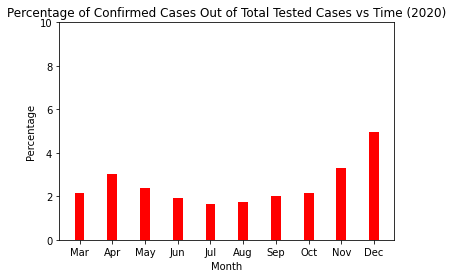

```python
main("canada-covid-19.csv")
```

```python
# Be sure to select ALL THE FILES YOU NEED (including csv's)
# when you submit. As usual, you cannot edit this cell.
# Instead, run this cell to start the submission process.
from cs103 import submit

COURSE = 101855
ASSIGNMENT = 1291659 # Final submission

submit(COURSE, ASSIGNMENT)

# If your submission fails, SUBMIT by downloading your files and uploading them
# to Canvas. You can learn how on the page "How to submit your Jupyter notebook"
# on our Canvas site.
```

```
We can't seem to find your token, if you need help finding it please see:
https://documentcloud.adobe.com/link/track?uri=urn%3Aaaid%3Ascds%3AUS%3A5a18408c-2102-4dc5-8f50-f8205f9b85bf
Please copy and paste your token here and then hit enter:
```

# Please double check your submission on Canvas to ensure that the right files (Jupyter file + CSVs) have been submitted and that the files do not contain unexpected errors.

**You should always check your submission on Canvas. It is your responsibility to ensure that the correct file has been submitted for grading.** Regrade or accomodation requests using reasoning such as "I didn't realize I submitted the wrong file"/"I didn't realize the submission didn't work"/"I didn't realize I didn't save before submitting so some of my work is missing" will not be considered.